# Predicting Bike Sharing Demand in the Cities

Modupeola Fagbenro, Crystal Kao, Guruksha Gurnani, Shanun Randev

2023-10-31

# Introduction

## Background of the study

As a direct quote from the data source:

``Bike sharing systems are a means of renting bicycles where the process of obtaining membership, rental, and bike return is automated via a network of kiosk locations throughout a city. Using these systems, people are able rent a bike from a one location and return it to a different place on an as-needed basis. Currently, there are over 500 bike-sharing programs around the world.

The data generated by these systems makes them attractive for researchers because the duration of travel, departure location, arrival location, and time elapsed is explicitly recorded. Bike sharing systems therefore function as a sensor network, which can be used for studying mobility in a city…” (Cukierski, 2014)

The data is specifically collected from the Capital Bikeshare program in Washington, D.C for 2011-2012.

## Problem Statement

In bustling urban centers characterized by heavy traffic and relatively short distances between points of interest, bike sharing has emerged as a viable alternative mode of transportation. Bike sharing allows individuals to conveniently rent bicycles from designated stations, without the requirement of returning them to the same station. Instead, there are numerous drop-off locations scattered throughout the city, offering increased flexibility in returning bicycles.

## Research Aim and Objectives

The objective of this research is to check factors that can influence Bike Sharing:

1. Checking Number of Urban Rentals Higher casual or registered population density in urban areas typically makes bike sharing more appealing due to shorter distances between destinations and increased demand for alternative transportation options.
2. Weather Conditions: Weather, such as temperature, humidity, or extreme heat, can impact bike sharing. Cities with more favorable weather conditions may see higher bike-sharing usage.
3. High-year Rentals: The increase in bikes year in and year out can be a result of good weather conditions or an increase in awareness of alternative means of transportation such as bike sharing.

## Research SMART Questions

Specific Measurable Achievable Relevant and Time-Bound Questions (SMART): Here are the SMART Questions, our analysis aims to answer:

1. Which variables are useful for predicting the number of bikes used in an hour?
2. How does temperature affect the number of bikes in use?
3. When do casual bikers increase the most?

Applying the SMART framework to our questions allows us to set clear objectives, measure progress, and ensure that the analysis provides meaningful insight for decision-makers/stakeholders in the context of bike sharing.

## Dataset Fields

- Datetime – The hour, date, and timestamp of each observation.
- Season: Categorical variable indicating the season, which can affect bike usage (e.g., 1-spring, 2-summer, 3-fall, 4-winter).
- Holiday: It’s binary variable indicating whether it’s a holiday (1 for yes, 0 for no)
- Working Day: It’s a binary variable indicating whether it’s a working day (1 for yes, 0 for no).
- Weather: Categorical variable representing different weather conditions, influencing bike ridership (e.g., clear, cloudy, rainy).
  - 1: Clear, Few clouds, Partly cloudy, Partly cloudy
  - 2: Mist + Cloudy, Mist + Broken clouds, Mist + Few clouds, Mist
  - 3: Light Snow, Light Rain + Thunderstorm + Scattered clouds, Light Rain + Scattered clouds
  - 4: Heavy Rain + Ice Pallets + Thunderstorm + Mist, Snow + Fog
- Temperature (temp): Temperature in Celsius, affecting user preferences for bike rides.
- Atemp : “Feels Like” Temperature (atemp): This column represents the “feels like” temperature, which takes into account factors such as wind chill and humidity to provide a more accurate perception of temperature. It can affect user comfort and, consequently, bike usage.
- Humidity: Humidity level, which can impact the comfort of cycling.
- Windspeed: Windspeed, another weather-related factor that affects bike riding conditions.
- Casual: The number of casual (non-registered) bike rentals.
- Registered: The number of registered bike rentals, indicating regular users of the bike sharing system.
- Count: The total count of bike rentals, which is the sum of casual and registered rentals, serving as the primary target variable for analysis and prediction.

Based on the above information, this data set allows us to explore how different factors including but not limited to weather conditions, time of the day, and humidity can impact bike-sharing trends and use these insights to improve bike-sharing systems.

## Dataset Limitations

1. Our Above data-set has limited variables and features, which has limitations, we are unable to explore the Pricing and Accessibility of bikes: The cost of bike-sharing services and easy the accessibility of bike stations can be significant factors in attracting users. Affordable pricing and convenient station locations encourage usage.
2. The data set does not include Bike Promotion and Marketing: Effective marketing, awareness, and promotion campaigns can boost bike-sharing programs’ visibility and encourage the participation of more people
3. The data-set did not explicitly have a Technological Integration features example The use of smartphone apps for finding bike locations and unlocking bikes, as well as using smartphones in tracking services, can make bike sharing more convenient and appealing to users and can lead to increase number of people willing to use bike sharing as an alternative way of transportation.
4. The data-set does not show Economic Factors features, the economic situation of the city’s residents, including income levels and employment opportunities, can influence the willingness to use bike-sharing services.
5. The data-set does not include the Competition level among bike sharing, The presence of other transportation options, such as public transit, taxis, or ride-sharing services, can affect bike-sharing adoption rates.

# Exploratory Data Analysis and Methodology

Performing exploratory data analysis (EDA) on a bike-sharing dataset is an essential step to gain insights and understand the data before diving into more advanced analyses. Here’s a step-by-step guide to performing EDA on a bike-sharing dataset and what methods we used:

## EDA Steps Conducted:

1. **Data Collection**: Start by obtaining the bike-sharing dataset from Kaggle. https://www.kaggle.com/competitions/bike-sharing-demand/data
2. **Data Loading**: Import the dataset into R studio data analysis environment.

```r
#Reading the CSV file into data frame
train_data <- read.csv('train.csv', stringsAsFactors = FALSE)
```

3. **Load Useful Packages**: The packages used in this analysis include: tidyverse, psych, ggthemes, ggplot2, dplyr, tidyr, corrgram, lubridate, caret, corrplot.

```r
#Loading libraries
library(tidyverse)
library(psych)
```

```r
library(ggthemes)
library(ggplot2) #for data visualization
library(dplyr) #for data manipulation
library(tidyr) #for tidying the data
library(corrgram)
library(lubridate)
library(caret)
library(corrplot)
```

4. **Data Overview**: Check the first few rows of the dataset to understand its structure and the kind of information it contains. Next check the data types of each column (e.g., categorical datatypes and numerical datatypes) to ensure they are correctly interpreted. Finally, inspect the columns (variables) in the dataset and their names.

```r
## Getting Data Frame dimensions
#displaying shape, number of columns, rows and first few rows of the data set
head(train_data)
```

```
##              datetime season holiday workingday weather temp  atemp humidity
## 1 2011-01-01 00:00:00      1       0          0       1 9.84 14.395       81
## 2 2011-01-01 01:00:00      1       0          0       1 9.02 13.635       80
## 3 2011-01-01 02:00:00      1       0          0       1 9.02 13.635       80
## 4 2011-01-01 03:00:00      1       0          0       1 9.84 14.395       75
## 5 2011-01-01 04:00:00      1       0          0       1 9.84 14.395       75
## 6 2011-01-01 05:00:00      1       0          0       2 9.84 12.880       75
##   windspeed casual registered count
## 1    0.0000      3         13    16
## 2    0.0000      8         32    40
## 3    0.0000      5         27    32
## 4    0.0000      3         10    13
## 5    0.0000      0          1     1
## 6    6.0032      0          1     1
```

```r
nrow(train_data)  # Number of rows, 10866
```

```
## [1] 10886
```

```r
ncol(train_data)  # Number of columns, 12
```

```
## [1] 12
```

```r
#Basic information about Data Frame
str(train_data)
```

```
## 'data.frame':    10886 obs. of  12 variables:
##  $ datetime  : chr  "2011-01-01 00:00:00" "2011-01-01 01:00:00" "2011-01-01 02:00:00" "2011-01-01 03:00:00" ...
##  $ season    : int  1 1 1 1 1 1 1 1 1 1 ...
##  $ holiday   : int  0 0 0 0 0 0 0 0 0 0 ...
##  $ workingday: int  0 0 0 0 0 0 0 0 0 0 ...
##  $ weather   : int  1 1 1 1 1 2 1 1 1 1 ...
##  $ temp      : num  9.84 9.02 9.02 9.84 9.84 ...
##  $ atemp     : num  14.4 13.6 13.6 14.4 14.4 ...
##  $ humidity  : int  81 80 80 75 75 75 80 86 75 76 ...
##  $ windspeed : num  0 0 0 0 0 ...
##  $ casual    : int  3 8 5 3 0 0 2 1 1 8 ...
##  $ registered: int  13 32 27 10 1 1 0 2 7 6 ...
##  $ count     : int  16 40 32 13 1 1 2 3 8 14 ...
```

```r
describe(train_data)
```

```
##            vars     n    mean      sd  median trimmed     mad  min      max
## datetime*     1 10886 5443.50 3142.66 5443.50 5443.50 4034.90 1.00 10886.00
## season        2 10886    2.51    1.12    3.00    2.51    1.48 1.00     4.00
## holiday       3 10886    0.03    0.17    0.00    0.00    0.00 0.00     1.00
## workingday    4 10886    0.68    0.47    1.00    0.73    0.00 0.00     1.00
## weather       5 10886    1.42    0.63    1.00    1.30    0.00 1.00     4.00
## temp          6 10886   20.23    7.79   20.50   20.23    9.73 0.82    41.00
## atemp         7 10886   23.66    8.47   24.24   23.76   10.11 0.76    45.45
## humidity      8 10886   61.89   19.25   62.00   62.09   22.24 0.00   100.00
## windspeed     9 10886   12.80    8.16   13.00   12.38    8.89 0.00    57.00
## casual       10 10886   36.02   49.96   17.00   25.30   22.24 0.00   367.00
## registered   11 10886  155.55  151.04  118.00  131.59  133.43 0.00   886.00
## count        12 10886  191.57  181.14  145.00  164.80  169.02 1.00   977.00
##               range  skew kurtosis    se
## datetime*  10885.00  0.00    -1.20 30.12
## season         3.00 -0.01    -1.36  0.01
## holiday        1.00  5.66    30.03  0.00
## workingday     1.00 -0.78    -1.40  0.00
## weather        3.00  1.24     0.39  0.01
## temp          40.18  0.00    -0.92  0.07
## atemp         44.70 -0.10    -0.85  0.08
## humidity     100.00 -0.09    -0.76  0.18
## windspeed     57.00  0.59     0.63  0.08
## casual       367.00  2.50     7.55  0.48
## registered   886.00  1.52     2.62  1.45
## count        976.00  1.24     1.30  1.74
```

5. **Data Cleaning**: Handle missing data by either imputing missing values or removing rows/columns with missing data. This data file luckily did not include any missing values or rows.
6. **Summary Statistics**: Calculate summary statistics like mean, median, standard deviation, and percentiles for numerical variables. This provides an initial understanding of the data distribution. For categorical variables, calculate frequency counts and proportions.

```r
summary(train_data) #summary statistics for the data frame
```

```
##    datetime             season         holiday          workingday
##  Length:10886       Min.   :1.000   Min.   :0.00000   Min.   :0.0000
##  Class :character   1st Qu.:2.000   1st Qu.:0.00000   1st Qu.:0.0000
##  Mode  :character   Median :3.000   Median :0.00000   Median :1.0000
##                     Mean   :2.507   Mean   :0.02857   Mean   :0.6809
##                     3rd Qu.:4.000   3rd Qu.:0.00000   3rd Qu.:1.0000
##                     Max.   :4.000   Max.   :1.00000   Max.   :1.0000
##     weather           temp           atemp          humidity
##  Min.   :1.000   Min.   : 0.82   Min.   : 0.76   Min.   :  0.00
##  1st Qu.:1.000   1st Qu.:13.94   1st Qu.:16.66   1st Qu.: 47.00
##  Median :1.000   Median :20.50   Median :24.24   Median : 62.00
##  Mean   :1.418   Mean   :20.23   Mean   :23.66   Mean   : 61.89
##  3rd Qu.:2.000   3rd Qu.:26.24   3rd Qu.:31.06   3rd Qu.: 77.00
##  Max.   :4.000   Max.   :41.00   Max.   :45.45   Max.   :100.00
##    windspeed          casual         registered        count
##  Min.   : 0.000   Min.   :  0.00   Min.   :  0.0   Min.   :  1.0
##  1st Qu.: 7.002   1st Qu.:  4.00   1st Qu.: 36.0   1st Qu.: 42.0
##  Median :12.998   Median : 17.00   Median :118.0   Median :145.0
##  Mean   :12.799   Mean   : 36.02   Mean   :155.6   Mean   :191.6
##  3rd Qu.:16.998   3rd Qu.: 49.00   3rd Qu.:222.0   3rd Qu.:284.0
##  Max.   :56.997   Max.   :367.00   Max.   :886.0   Max.   :977.0
```

7. **Data Visualization**: Create visualizations to gain insights into the data. Some plots we used include scatterplots, box plots, bar charts, and correlation matrices.

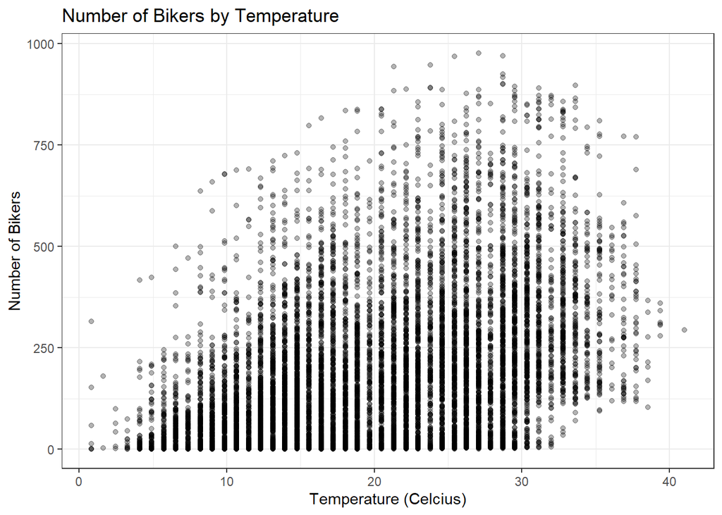

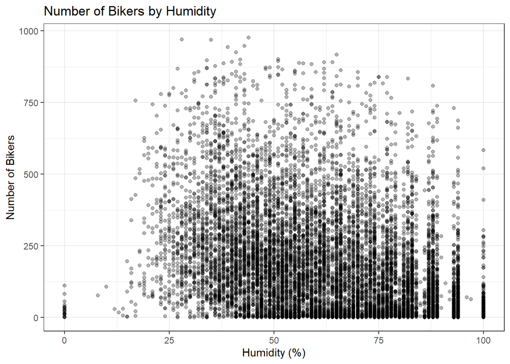

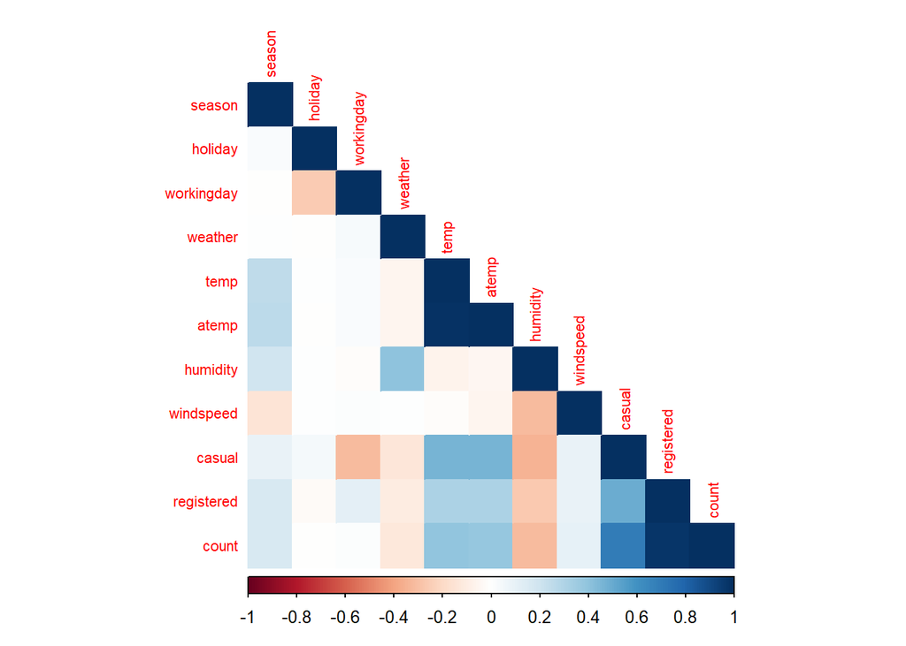

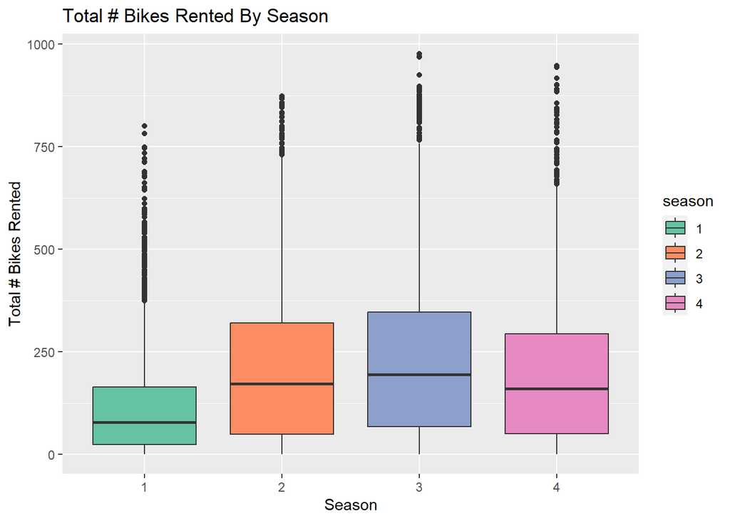

8. **Distributions and Patterns**: Examine the distribution of the target variable(s) (e.g., bike rentals) and potential predictor variables. For this analysis, we looked at bikers by temperature, bikers by humidity, and bikers by season, which will all be shown in the results section as they pertain to our SMART questions.

# Changes Made After EDA

After doing some EDA, some of our questions changed to adhere more to what made more sense for our data to answer and focus in on answering more pointed questions. For example, one of our original questions was which variable has the highest effect on the count of the number of bikes used in a day? However, due to the way the data is collected and the purpose of the dataset, it made more sense to change the question to which variables are useful for predicting the number of bikes used in an hour? Since the data is collected hourly and creating a model instead of looking for a specific variable made more sense. The model can be used to predict future bike sharing rates.

# Model Selection and Hypothesis Testing

Since we were interested in learning about which variables influence the number of bikers in a given hour, we wanted to create a linear regression model. Before doing so, we needed to format our data appropriately. We created new fields based on the ‘Datetime’ column to split out the year, day, month, hour and day of the week. ‘Season’ and ‘weather’ are categorical variables and were represented using dummy variables.

```r
train_data$datetime <- as.POSIXct(train_data$datetime)


extract_feature <- function(df) {
  df <- df %>%
    mutate(
      year = year(datetime),
      day = day(datetime),
      month = month(datetime),
      hour = hour(datetime),
      dayofweek = wday(datetime) - 1
    )

  return(df)
}


train_data$weather <- as.factor(train_data$weather)



train_data <- extract_feature(train_data)
```

We first started out by running a linear model on the data with ‘count’ as the dependent variable and all other available variables as the predictors (this is considered Model 1). However, we excluded ‘registered’ and ‘casual’ because they sum up to the ‘count’.

```r
train_data <- train_data %>% select(-datetime)


training_df <- train_data[, !colnames(train_data) %in% c("casual","registered")]


lm_model <- lm(count ~ ., data = training_df)

print(summary(lm_model))
```

```
##
## Call:
## lm(formula = count ~ ., data = training_df)
##
## Residuals:
##     Min      1Q  Median      3Q     Max
## -328.49  -93.16  -27.79   61.37  633.12
##
## Coefficients:
##               Estimate Std. Error t value Pr(>|t|)
## (Intercept) -1.634e+05  5.480e+03 -29.824  < 2e-16 ***
## season2     -1.621e+00  6.882e+00  -0.235  0.81384
## season3     -4.935e+01  1.156e+01  -4.268 1.99e-05 ***
## season4     -1.061e+01  1.547e+01  -0.686  0.49292
## holiday     -2.813e+00  8.468e+00  -0.332  0.73975
## workingday  -6.634e-01  2.996e+00  -0.221  0.82476
## weather2     6.558e+00  3.289e+00   1.994  0.04619 *
## weather3    -2.979e+01  5.557e+00  -5.360 8.49e-08 ***
## weather4     6.773e+01  1.407e+02   0.481  0.63039
## temp         5.107e+00  1.103e+00   4.629 3.73e-06 ***
## atemp        2.848e+00  9.675e-01   2.943  0.00325 **
## humidity    -1.909e+00  8.861e-02 -21.540  < 2e-16 ***
## windspeed    5.404e-01  1.821e-01   2.967  0.00301 **
## year         8.124e+01  2.724e+00  29.824  < 2e-16 ***
## day          3.202e-01  2.465e-01   1.299  0.19397
## month        8.969e+00  1.674e+00   5.357 8.64e-08 ***
## hour         7.679e+00  2.089e-01  36.765  < 2e-16 ***
## dayofweek    2.676e+00  6.788e-01   3.942 8.13e-05 ***
## ---
## Signif. codes:  0 '***' 0.001 '**' 0.01 '*' 0.05 '.' 0.1 ' ' 1
##
## Residual standard error: 140.6 on 10868 degrees of freedom
## Multiple R-squared:  0.3982, Adjusted R-squared:  0.3972
## F-statistic:   423 on 17 and 10868 DF,  p-value: < 2.2e-16
```

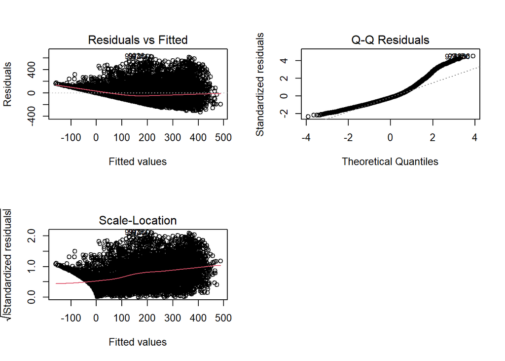

```r
par(mfrow = c(2,2))
plot(lm_model, which = c(1,2,3))
```

Based on the results of the residuals vs fitted plot, the variance of residuals increased as the values increased.

A log transformation was considered to see if there was a model with more constant variance. Because of this, we also ran a version of the model with a log transformation on the ‘count’ field to see if the normality assumption would be more reasonable on the log scale (this is considered Model 2).

```r
lm_model2 <- lm(log(count) ~ ., data = training_df)
summary(lm_model2)
```

```
##
## Call:
## lm(formula = log(count) ~ ., data = training_df)
##
## Residuals:
##     Min      1Q  Median      3Q     Max
## -4.0840 -0.6233  0.1166  0.6861  3.1649
##
## Coefficients:
##               Estimate Std. Error t value Pr(>|t|)
## (Intercept) -8.583e+02  4.139e+01 -20.737  < 2e-16 ***
## season2     -1.118e-02  5.198e-02  -0.215  0.82968
## season3     -3.449e-01  8.735e-02  -3.949 7.90e-05 ***
## season4     -3.988e-02  1.168e-01  -0.341  0.73292
## holiday     -4.406e-02  6.396e-02  -0.689  0.49088
## workingday  -9.960e-02  2.263e-02  -4.402 1.09e-05 ***
## weather2     1.465e-01  2.484e-02   5.897 3.81e-09 ***
## weather3    -2.447e-01  4.197e-02  -5.831 5.67e-09 ***
## weather4     1.111e+00  1.063e+00   1.046  0.29581
## temp         3.452e-02  8.334e-03   4.142 3.47e-05 ***
## atemp        2.265e-02  7.308e-03   3.100  0.00194 **
## humidity    -1.383e-02  6.693e-04 -20.664  < 2e-16 ***
## windspeed    4.525e-03  1.376e-03   3.289  0.00101 **
## year         4.280e-01  2.058e-02  20.800  < 2e-16 ***
## day          2.728e-03  1.862e-03   1.465  0.14290
## month        6.915e-02  1.265e-02   5.468 4.64e-08 ***
## hour         1.024e-01  1.578e-03  64.901  < 2e-16 ***
## dayofweek    2.306e-02  5.127e-03   4.498 6.92e-06 ***
## ---
## Signif. codes:  0 '***' 0.001 '**' 0.01 '*' 0.05 '.' 0.1 ' ' 1
##
## Residual standard error: 1.062 on 10868 degrees of freedom
## Multiple R-squared:  0.4919, Adjusted R-squared:  0.4911
## F-statistic: 618.9 on 17 and 10868 DF,  p-value: < 2.2e-16
```

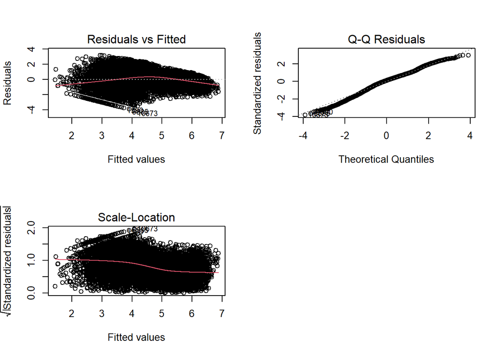

```r
par(mfrow = c(2,2))
plot(lm_model2, which = c(1,2,3))
```

With this new model, the residuals vs fitted plot no longer increased as the values increased, and the qq-plot also shows that normality is a reasonable assumption. Noticing that ‘holiday’ and ‘day’ were not statistically significant in this model based on the t-tests, we created another model based on the log transformed model where ‘holiday’ and ‘day’ were taken out (this model is considered Model 3).

```r
lm_model3 <- lm(log(count) ~ .-holiday -day, data = training_df) # no holiday and day
```

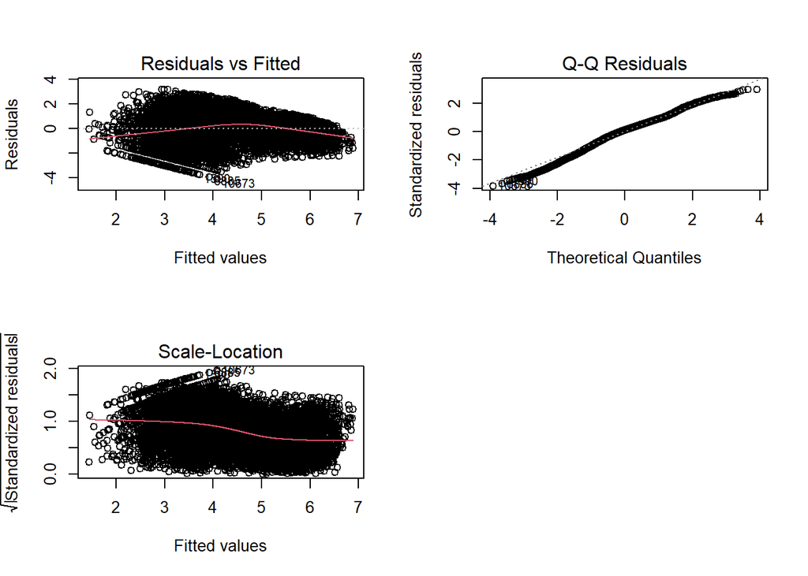

```r
par(mfrow = c(2,2))
plot(lm_model3, which = c(1,2,3))
```

An ANOVA was then run on this model with the following hypotheses:

```
Null Hypothesis: Model 3 is a reasonable fit

Alternative Hypothesis: Model 2 is a reasonable fit
```

```r
anova(lm_model3,lm_model2)
```

```
## Analysis of Variance Table
##
## Model 1: log(count) ~ (season + holiday + workingday + weather + temp +
##     atemp + humidity + windspeed + year + day + month + hour +
##     dayofweek) - holiday - day
## Model 2: log(count) ~ season + holiday + workingday + weather + temp +
##     atemp + humidity + windspeed + year + day + month + hour +
##     dayofweek
##   Res.Df   RSS Df Sum of Sq      F Pr(>F)
## 1  10870 12266
## 2  10868 12263  2    2.9945 1.3269 0.2653
```

The p-value is greater than 0.05, so we do not reject the null hypothesis, which means Model 3 is adequate to model the rentals. There’s no evidence that including ‘holiday’ and ‘day’ improves the model’s fit.

An ANOVA was also run on Model 3 to confirm that all the variables included have statistical significance even after adjustment for the other variables. If any of the variables were not statistically significant, we would have continued our model selection by removing those variables. However, all the variables were statistically significant, so we continued our analysis with Model 3.

```r
summary(lm_model3)
```

```
##
## Call:
## lm(formula = log(count) ~ . - holiday - day, data = training_df)
##
## Residuals:
##     Min      1Q  Median      3Q     Max
## -4.0825 -0.6250  0.1178  0.6854  3.1564
##
## Coefficients:
##               Estimate Std. Error t value Pr(>|t|)
## (Intercept) -8.580e+02  4.139e+01 -20.730  < 2e-16 ***
## season2     -1.410e-02  5.186e-02  -0.272 0.785798
## season3     -3.516e-01  8.696e-02  -4.044 5.30e-05 ***
## season4     -4.886e-02  1.161e-01  -0.421 0.673989
## workingday  -9.544e-02  2.192e-02  -4.354 1.35e-05 ***
## weather2     1.466e-01  2.484e-02   5.900 3.74e-09 ***
## weather3    -2.456e-01  4.196e-02  -5.853 4.96e-09 ***
## weather4     1.111e+00  1.063e+00   1.045 0.296008
## temp         3.451e-02  8.325e-03   4.145 3.42e-05 ***
## atemp        2.271e-02  7.301e-03   3.110 0.001875 **
## humidity    -1.383e-02  6.693e-04 -20.659  < 2e-16 ***
## windspeed    4.587e-03  1.375e-03   3.336 0.000852 ***
## year         4.278e-01  2.058e-02  20.793  < 2e-16 ***
## month        7.011e-02  1.257e-02   5.577 2.50e-08 ***
## hour         1.024e-01  1.578e-03  64.892  < 2e-16 ***
## dayofweek    2.340e-02  5.103e-03   4.586 4.58e-06 ***
## ---
## Signif. codes:  0 '***' 0.001 '**' 0.01 '*' 0.05 '.' 0.1 ' ' 1
##
## Residual standard error: 1.062 on 10870 degrees of freedom
## Multiple R-squared:  0.4918, Adjusted R-squared:  0.4911
## F-statistic: 701.2 on 15 and 10870 DF,  p-value: < 2.2e-16
```

```r
anova(lm_model3)
```

```
## Analysis of Variance Table
##
## Response: log(count)
##               Df  Sum Sq Mean Sq  F value    Pr(>F)
## season         3  1216.0   405.3  359.189 < 2.2e-16 ***
## workingday     1     7.8     7.8    6.916 0.0085546 **
## weather        3   314.1   104.7   92.790 < 2.2e-16 ***
## temp           1  3155.7  3155.7 2796.544 < 2.2e-16 ***
## atemp          1    12.5    12.5   11.084 0.0008735 ***
## humidity       1  1952.6  1952.6 1730.369 < 2.2e-16 ***
## windspeed      1    33.6    33.6   29.776 4.956e-08 ***
## year           1   358.7   358.7  317.849 < 2.2e-16 ***
## month          1    50.6    50.6   44.882 2.196e-11 ***
## hour           1  4743.5  4743.5 4203.623 < 2.2e-16 ***
## dayofweek      1    23.7    23.7   21.027 4.579e-06 ***
## Residuals  10870 12266.0     1.1
## ---
## Signif. codes:  0 '***' 0.001 '**' 0.01 '*' 0.05 '.' 0.1 ' ' 1
```

# Results

After going through all the processes in our pipeline we are able to answer our 3 SMART questions. In the first question we need to extract the features which are useful for predicting the number of bikes used in an hourly granularity. After doing model selection based on the linear regression models, we came to the conclusion that the variables ‘holiday’ and ‘day’ are not statistically significant variables, unlike the other variables. Model 3 proved to be the most adequate model for the rental of bikes per hour due to the ANOVA we ran to compare Model 3 and Model 2. The additional ANOVA ran on Model 3 also proved that removing any more of the variables would reduce model fit. This means that all the variables other than ‘holiday’ and ‘day’ are significant and important for predicting the number of bike rentals in an hour. The final list of variables that are useful for predicting the number of bikes used in an hour are ‘season’, ‘working day’, ‘weather’, ‘temp’, ‘atemp’, ‘humidity’, ‘windspeed’, ‘year’, ‘month’, ‘hour’, and ‘dayofweek’.

```r
summary(lm_model3)
```

```
##
## Call:
## lm(formula = log(count) ~ . - holiday - day, data = training_df)
##
## Residuals:
##     Min      1Q  Median      3Q     Max
## -4.0825 -0.6250  0.1178  0.6854  3.1564
##
## Coefficients:
##               Estimate Std. Error t value Pr(>|t|)
## (Intercept) -8.580e+02  4.139e+01 -20.730  < 2e-16 ***
## season2     -1.410e-02  5.186e-02  -0.272 0.785798
## season3     -3.516e-01  8.696e-02  -4.044 5.30e-05 ***
## season4     -4.886e-02  1.161e-01  -0.421 0.673989
## workingday  -9.544e-02  2.192e-02  -4.354 1.35e-05 ***
## weather2     1.466e-01  2.484e-02   5.900 3.74e-09 ***
## weather3    -2.456e-01  4.196e-02  -5.853 4.96e-09 ***
## weather4     1.111e+00  1.063e+00   1.045 0.296008
## temp         3.451e-02  8.325e-03   4.145 3.42e-05 ***
## atemp        2.271e-02  7.301e-03   3.110 0.001875 **
## humidity    -1.383e-02  6.693e-04 -20.659  < 2e-16 ***
## windspeed    4.587e-03  1.375e-03   3.336 0.000852 ***
## year         4.278e-01  2.058e-02  20.793  < 2e-16 ***
## month        7.011e-02  1.257e-02   5.577 2.50e-08 ***
## hour         1.024e-01  1.578e-03  64.892  < 2e-16 ***
## dayofweek    2.340e-02  5.103e-03   4.586 4.58e-06 ***
## ---
## Signif. codes:  0 '***' 0.001 '**' 0.01 '*' 0.05 '.' 0.1 ' ' 1
##
## Residual standard error: 1.062 on 10870 degrees of freedom
## Multiple R-squared:  0.4918, Adjusted R-squared:  0.4911
## F-statistic: 701.2 on 15 and 10870 DF,  p-value: < 2.2e-16
```

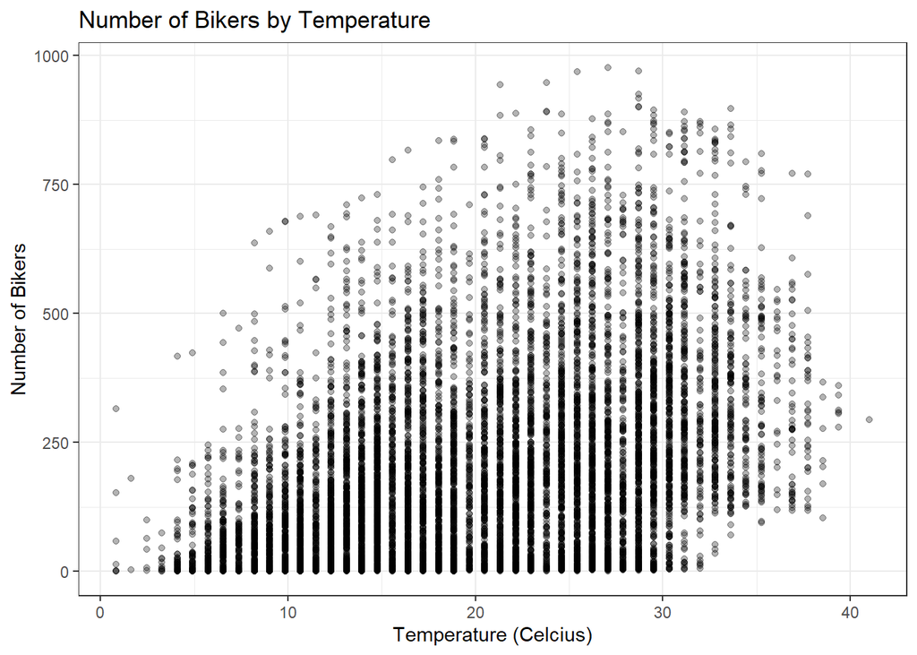

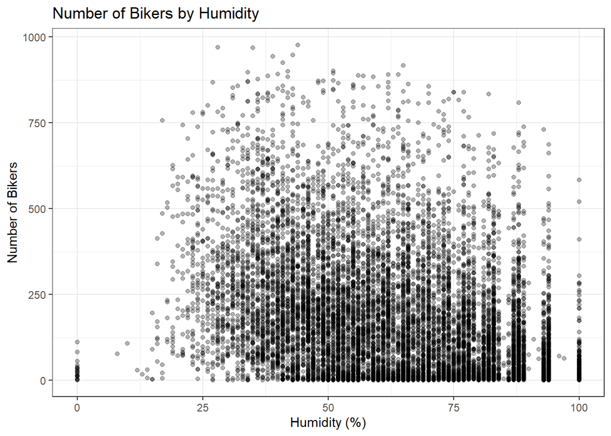

Our final model (Model 3) also shows a slight increase in the number of rental counts when temperature increases due to the positive coefficient in the table.

```
## [1] 0.03451103
```

In the third smart question we need to answer when do the casual (or non-registered) bikers increase the most. To answer this question, we plotted a scatterplot between temperature and the number of casual bike users. The number of casual bike rentals increased when the temperature increased but dropped off once the temperature started going beyond 30 degrees Celsius. Most of them rented bikes when the temperature was between 20-30 degrees Celsius. In Fahrenheit that is between 68-86 degrees. Again, this makes sense as people tend to go outside only when the temperature is nice and not too hot or cold.

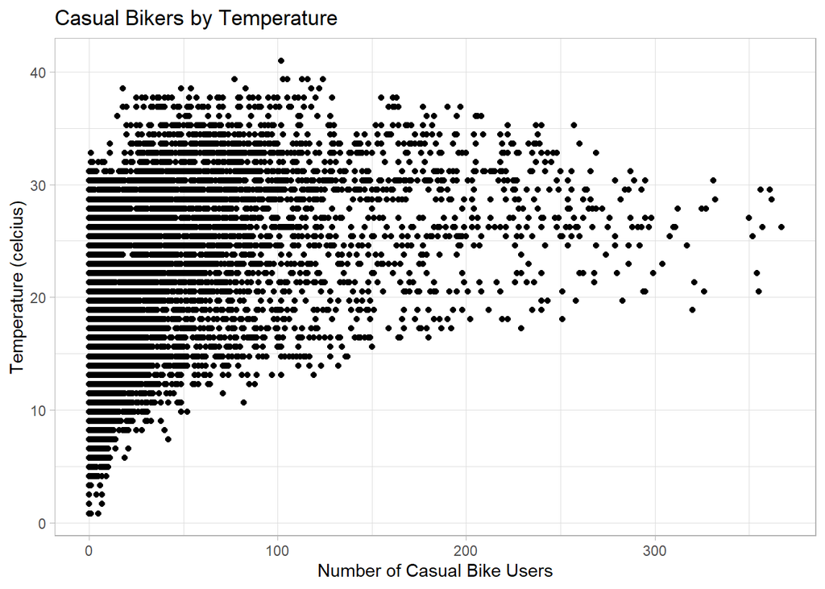

```r
ggplot(train_data, aes(casual, temp))+ geom_point() + theme_light() +
  labs(x = "Number of Casual Bike Users",
       y = "Temperature (celcius)",
       title = "Casual Bikers by Temperature")
```

# Conclusions/Next Steps

In conclusion, through the process of this analysis, we were able to explore the bike sharing data provided and practiced EDA while also learning how to create models and to help answer our SMART questions. As a potential next step for future consideration, we will use the model we selected to generate predictions on a test dataset by predicting the number of bike rentals per hour. We will also try to use some more advanced techniques like hyperparameter tuning and model pruning if we get high error scores.

## Additional Beneficial Information

Sustainability Goals for increasing Bike usage in different Cities Urban Municipal cities’ commitments to sustainability and reducing congestion and pollution can drive the adoption of bike sharing as a sustainable transportation solution. Sustainability Bike sharing and usage have significance and can vary from one city or region to another. Successful bike-sharing programs often consider these factors when planning and implementing their services.

# References

Cukierski, W. (2014). Bike Sharing Demand. Kaggle. https://www.kaggle.com/competitions/bike-sharing-demand/overview